# Data Analysis

Balakrishna,D

Summer Full 2023

### Establishing SQLite and MySQL Connections

```r
library(RSQLite)

sqlite_con <- dbConnect(RSQLite::SQLite(), "pharma.sqlite")
library(RMySQL)

db_name_fh <- "sql9639719"
db_user_fh <- "sql9639719"
db_host_fh <- "sql9.freemysqlhosting.net"
db_pwd_fh <- "3ULuvSERWS"
db_port_fh <- 3306

mysql_con <-  dbConnect(RMySQL::MySQL(), user = db_user_fh, password = db_pwd_fh,
                   dbname = db_name_fh, host = db_host_fh, port = db_port_fh)
```

### Analytical Query I

For Query I, we firstly extract the needed data from the fact tables that were created in the previous part of the assignment. Let us select the top 5 reps from the rep_facts table ordering it by the sales each person made that particular year.

```r
query <- "
SELECT firstName, lastName,
  y2020_sold,
  y2021_sold,
  y2022_sold
FROM rep_facts
ORDER BY y2020_sold DESC
LIMIT 5;"

top_reps <- dbGetQuery(mysql_con, query)

print(knitr::kable(top_reps))
```

| firstName | lastName | y2020_sold | y2021_sold | y2022_sold |
| --- | --- | --- | --- | --- |
| Walison | da Silva | 1278700 | 0 | 0 |
| Aneeta | Kappoorthy | 914800 | 0 | 0 |
| Lynette | McRowe | 678100 | 0 | 0 |
| Prasad | Patel | 465800 | 0 | 0 |
| Helmut | Schwab | 454900 | 0 | 0 |

So we can see the names of the top 5 reps in the year 2020. As the data only had records from the year 2020, we can only observe values in the column of that particular year.

### Analytical Query II

For the second query we can see the total sales by using the SUM function in SQL. We also create a second table for visualization.

```r
total <- dbGetQuery(mysql_con, "
  SELECT
    SUM(y2020_sold) AS y2020,
    SUM(y2021_sold) AS y2021,
    SUM(y2022_sold) AS y2022
  FROM rep_facts
")
print(total)
```

| y2020 | y2021 | y2022 |
| --- | --- | --- |
| 4123300 | 0 | 0 |

```r
years <- dbGetQuery(mysql_con, "
  SELECT
    2020 AS year, SUM(y2020_sold) AS total
  FROM rep_facts

  UNION

  SELECT
    2021 AS year, SUM(y2021_sold) AS total
  FROM rep_facts

  UNION

  SELECT
    2022 AS year, SUM(y2022_sold) AS total
  FROM rep_facts
")
```

In this part, we visualize the data that we computed above in the form of a Line Plot, now as previously specified the data only contains values for the year 2020, so we would get a linear plot and then a zero line for 2021 and 2022.

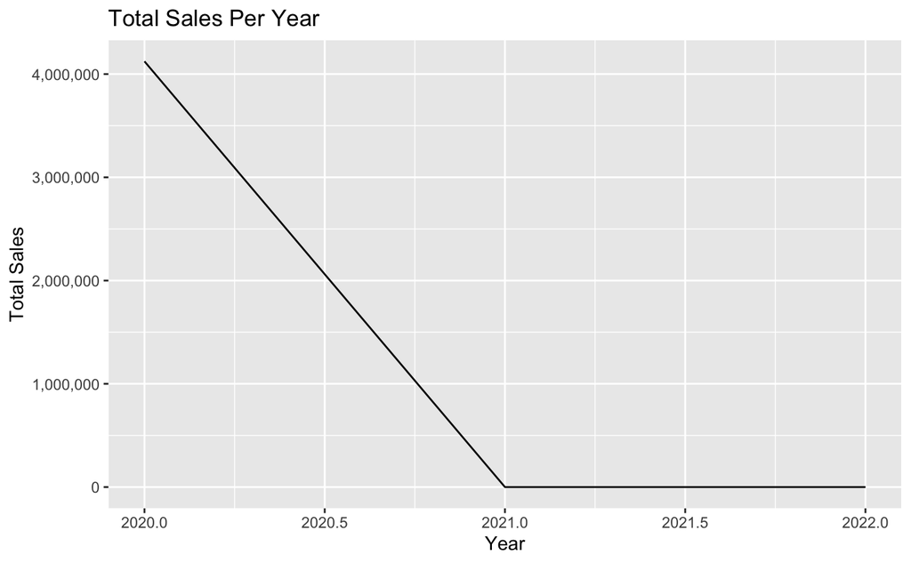

```r
library(ggplot2)
ggplot(years, aes(x = year, y = total)) +
  geom_line() +
  scale_y_continuous(labels = scales::comma) +
  labs(
    title = "Total Sales Per Year",
    x = "Year",
    y = "Total Sales"
  )
```

We can see that a little over 4 Million products were sold in the year 2020.